# **Decoding Health Outcomes Across the American Landscape**

Final Project

Mia, Oliver, Hemen

2026-04-23

```r
library(tidyverse)
library(ggplot2)
library(ggpmisc)
library(viridis)
library(readr)
library(caret)
library(ggpubr)
library(gridExtra)
library(maps)

my_data <- read.csv("U.S.ChronicDiseaseIndicators.csv",na.strings = "")
```

## **Introduction**

Health problems and outcomes are not experienced and distributed equally across different ethnic groups in the United States. Differences in chronic disease rates (for example, heart disease, cancer, and strokes) often reflect economic and social inequalities such as access to healthcare and socioeconomic status. In this project, we try to find out how different ethnic groups in the United States are affected or not affected by various chronic diseases such as heart disease and invasive cancers. We also want to investigate what socioeconomic factors–such as poverty and health insurance access–and lifestyle factors–such as physical activity and cigarette smoking–may be tied to these said differences in health outcomes. We focus closely on the differences between Hispanic populations and other ethnic groups due to the paradoxical findings we discovered while investigating various relationships. We try to find potential reasons for the paradoxical results seen in Hispanic populations which guided what relationships we investigated.

The question of how various socioeconomic and lifestyle factors affect health outcomes for different ethnic groups is an important question since the inequality between different ethnic groups tends to lead towards worse outcomes for minority groups. Certain ethnic groups experience disproportionately higher risks for specific chronic conditions due to socioeconomic differences. Identifying what factors may be benefiting or hindering health outcomes for different ethnic groups is crucial to the effective allocation of resources to communities and populations that are at higher risk for chronic illness. Additionally, identifying where and how systematic discrimination affects different ethnic groups is crucial to the creation of policy to combat systematic discrimination in the future. Furthermore, identifying lifestyle differences that may lead to better outcomes is important to bettering the health outcomes of all people, regardless of ethnicity.

Data used for analysis in this project comes from the CDCs Chronic Disease Indicators dataset- a dataset that is available publicly and that compiles health information across all US states and territories and was collected through surveillance efforts by public health agencies from 2015 to 2022 (with updates made as recent as October 2024). Each row/observation in the dataset represents a specific health indicator for a state and ethnic group. By examining the relationships between different variables, these data will allow us to compare different health outcomes across different ethnic groups and states in the United States.

## Investigating Inequalities Across Different Ethnic Groups

### Variation in Confidence Interval Across Ethnic Groups

```r
themeMOH <- function() {
    theme(
        text = element_text(family = "sans" ),
        legend.text = element_text(size = rel(0.8)),
        legend.title = element_text(size = rel(1), face = "bold"),
        panel.border = element_rect(
            linewidth = rel(2),
            linejoin = "round",
            color = alpha(colour = "black", alpha = .5)
        ),
        panel.background = element_rect(fill = alpha(
            alpha = .15, colour = "#6A89A7"
        )),
        panel.grid.minor.x = element_line(linewidth = 0),
        panel.grid.major.x = element_line(
            color = "grey70",
            linetype = "dotted",
            linewidth = rel(1)
        ),
        panel.grid.minor.y = element_line(linewidth = 0),
        panel.grid.major.y = element_line(
            color = "grey30",
            linetype = "dotted",
            linewidth = rel(1.5)
        ),
     strip.background = element_rect(
            fill = alpha(
                alpha = .35,
                colour = "#6A89A7"),
            color = alpha(colour = "black", alpha = .5)
        ))
}


#{r Load In,message=FALSE,warning=FALSE}
HealthData<-my_data|>
  select(
    LocationAbbr,
    LocationDesc,
    YearStart,
    YearEnd,
    Question,
    QuestionID,
    StratificationCategory1,
    Stratification1,
    DataValue,
    LowConfidenceLimit,
    HighConfidenceLimit,
    DataValueUnit,
    DataValueType,
    Geolocation)|>
  mutate(
    Stratification1 = fct(Stratification1),
    Stratification1 = fct_recode(
      Stratification1,
      F = "Female",
      M = "Male",
      Hispanic = "Hispanic",
      White = "White, non-Hispanic",
      Black = "Black, non-Hispanic",
      API = "Asian or Pacific Islander, non-Hispanic",
      HPI = "Hawaiian or Pacific Islander, non-Hispanic",
      Asian = "Asian, non-Hispanic",
      Multiracial = "Multiracial, non-Hispanic",
      NativeAmerican = "American Indian or Alaska Native, non-Hispanic"),

    #======================================
    #_c means crude, _aa means age-adjusted
    #======================================

    DataValueType = fct(DataValueType),
    DataValueType = fct_recode(
      DataValueType,
      mean_aa = "Age-adjusted Mean",
      mean_c = "Crude Mean",
      rate_aa = "Age-adjusted Rate",
      rate_c = "Crude Rate",
      prev_aa = "Age-adjusted Prevalence",
      prev_c = "Crude Prevalence",
      median_c = "Crude Median",
      c_75pct = "Crude 75th percentile"),

    DataValueUnit = fct(DataValueUnit),
    DataValueUnit = fct_collapse(
      DataValueUnit,
      per_100k = c("per 100,000","cases per 100,000")),
    )



StratSelect <- c("White", "Black","Hispanic","NativeAmerican","Asian","Overall")
Renamelist <- c(
    InvasiveIncidence = "CAN07",
    InvasiveMortality = "CAN08",
    LungMortality = "CAN04",
    CorectalMortality = "CAN01",
    CorectalScreening = "CAN06",
    BrestMortaltity = "CAN02",
    BrestScreening = "CAN09",
    CervicalMortality = "CAN03",
    CervicalScreening = "CAN10",
    RoutineCheckup = "SDH12",
    LivingBelow1.5Poverty = "SDH01",
    LiverDisease = "ALC09",
    CorHeartMortality = "CVD08",
    HeartDiseaseMortality = "CVD09",
    HighBP = "CVD01",
    StrokeMortality = "CVD07",
    HighCholesterol = "CVD03",
    NoHealthInsurance18to64 = "SDH09",
    BingeDrinkingPrev = "ALC06",
    NoLeisureTime = "NPW06",
    Obesity = "NPW14",
    LackOfHealthInsurance = "SDH09",
    CigaretteSmoking = "TOB04",
    FairOrPoorHealth = "HEA01",
    AvePhysicalyUnhealthyDays = "HEA02",
    MetPhysicalActivityGuideline = "NPW09",
    Vegetables = "NPW04"

)
filterlist<- list(
    expr(DataValueUnit %in% c("per_100k", "%")|(QuestionID %in% c("HEA02","CVD06"))),
    expr(!is.na(DataValue)),
    expr(StratificationCategory1 %in% c("Race/Ethnicity","Overall")),
    expr(Stratification1 %in% StratSelect),
    expr(DataValueType %in% c("rate_aa", "prev_aa") |
        (QuestionID == "SDH01" & DataValueType == "prev_c")|(QuestionID == "HEA02"& DataValueType == "mean_aa")),
    expr(YearStart %in% c(2016) |
        (YearStart == 2020 & QuestionID %in% c("CAN06","CAN09","CAN10")) |
        (YearStart == 2021 & QuestionID %in% c("SDH12","SDH01","ALC09","CVD08","CVD01","CVD07","CVD03","NPW04","SDH09","CVD06","CVD09")) |
        (YearStart == 2019 & QuestionID %in% c("NPW09")) |
        (YearStart == 2022 & QuestionID %in% c("ALC06","NPW06","NPW14","TOB04","MEN02","MEN05","HEA01","HEA02")))
    )


StateHealth <- HealthData |>
    filter(
        !!!filterlist
        )|>
    group_by(LocationAbbr, StratificationCategory1, Stratification1) |>
    select(LocationAbbr,
           LocationDesc,
           Stratification1,
           StratificationCategory1,
           QuestionID,
           DataValue)|>
    pivot_wider(names_from = QuestionID, values_from = DataValue) |>
    rename(Renamelist
           )|>
    mutate(
        InvasiveDeathRate = InvasiveMortality/InvasiveIncidence
        )


# {r No Pivot Set Up,message=FALSE,warning=FALSE}
StratSelect <- c("White", "Black","Hispanic","NativeAmerican","Asian"
                 )
Renamelist <- list(
    "InvasiveIncidence" = "CAN07",
    "InvasiveMortality" = "CAN08",
    "LungMortality" = "CAN04",
    "CorectalMortality" = "CAN01",
    "CorectalScreening" = "CAN06",
    "BrestMortaltity" = "CAN02",
    "BrestScreening" = "CAN09",
    "CervicalMortality" = "CAN03",
    "CervicalScreening" = "CAN10",
    "RoutineCheckup" = "SDH12",
    "LivingBelow1.5Poverty" = "SDH01",
    "LiverDisease" = "ALC09",
    "CorHeartDiseaseMortality" = "CVD08",
    "HighBP" = "CVD01",
    "StrokeMortality" = "CVD07",
    "HighCholesterol" = "CVD03",
    "NoHealthInsurance18to64" = "SDH09",
    "BingeDrinkingPrev" = "ALC06",
    "NoLeisureTime" = "NPW06",
    "Obesity" = "NPW14",
    "LackOfHealthInsurance" = "SDH09",
    "CigaretteSmoking" = "TOB04",
    "HeartDiseaseMortality" = "CVD09"

)



StateHealthNoPivot <- HealthData|>
    filter(
        !!!filterlist
        )|>
    select(LocationAbbr,
           Stratification1,
           StratificationCategory1,
           QuestionID,
           DataValue,HighConfidenceLimit,LowConfidenceLimit,DataValueUnit,DataValueType)|>
    mutate(
        QuestionID = fct(QuestionID),
        QuestionID = fct_recode(
            QuestionID,!!!Renamelist),
        CI = HighConfidenceLimit - LowConfidenceLimit,
        MOE = CI/2
        )


mostvaried <- function(n){
    x<- StateHealthNoPivot|>
    filter(QuestionID != "HeartDiseaseMortality")|>
    filter(!is.na(MOE))|>
    group_by(QuestionID,Stratification1)|>
    summarise(medianMOE=median(MOE))|>
    ungroup()|>
    group_by(QuestionID)|>
    summarise(variance=max(medianMOE)-mean(medianMOE))|>
    slice_max(variance,n=n)|>
    select(QuestionID)

x<-as.vector(x[["QuestionID"]])
}
```

**Figure 1:**

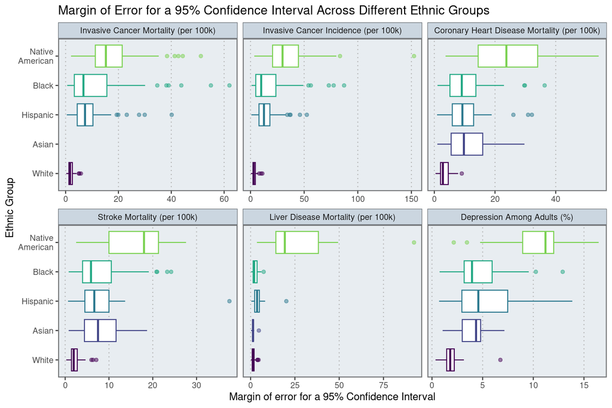

Figure 1. The margin of error has a large amount of variation across different ethnic groups, with ethnic groups such as Native Americans displaying the largest margin of error (this can indicate a smaller sample size or larger variability). Data are from the CDC Chronic Disease Indicators dataset (from 2015 to 2022) and represent the 95% confidence interval margin of error of multiple different chronic disease outcomes across U.S States. Boxplots summarize the distributions across the U.S states and health indicators, grouped by different ethnicities. The plot showing the margine of error for of depression among adults exemplifies how weak the data for Native American populations are with the average 95% confidence interval having a margin of about ±11%

```r
StateHealthNoPivot |>
    filter(!is.na(MOE), QuestionID %in% mostvaried(6)) |>
    mutate(
        Stratification1 = fct_reorder(Stratification1, MOE, .fun = "max"),
        Stratification1 = fct_recode(
            Stratification1,
            "Native\nAmerican" = "NativeAmerican"),
        QuestionID = fct_recode(
            QuestionID,
            "Invasive Cancer Mortality (per 100k)" = "InvasiveMortality",
            "Invasive Cancer Incidence (per 100k)" = "InvasiveIncidence",
            "Coronary Heart Disease Mortality (per 100k)" = "CorHeartDiseaseMortality",
            "Stroke Mortality (per 100k)" = "StrokeMortality",
            "Liver Disease Mortality (per 100k)" = "LiverDisease",
            "Depression Among Adults (%)" = "MEN02"
        )
        ) |>
    group_by(QuestionID, Stratification1) |>
    ggplot(aes(
        y = Stratification1,
        color = Stratification1
    ))+
    geom_boxplot(aes(x = MOE), show.legend = F, outlier.alpha = .5)+
    facet_wrap(~ QuestionID, scales = "free_x")+
    labs(
        y = "Ethnic Group",
        x = "Margin of error for a 95% Confidence Interval",
        title = "Margin of Error for a 95% Confidence Interval Across Different Ethnic Groups"
    )+
    themeMOH()+
    theme(
        panel.grid.major.y = element_line(linewidth = 0)
        )+
    scale_color_viridis(discrete = TRUE, end = .8,direction = 1)
```

**Figure 1 Interpretation:** Widths of the confidence intervals vary a substantial amount across the five different ethnic groups- Native American, Black, Hispanic, Asian and White. White individuals have the narrowest and more compact confidence intervals. Native Americans show the largest confidence intervals. This suggests that there is more variability in the health outcomes (or maybe just smaller sample sizer for this ethnic group which can reduce the precision of our estimates) for Native American populations. Our project aims to compare different chronic conditions across different ethnic groups in the U.S., the possibility of having precision reduced is an important factor to consider when we are interpreting the graphs. Wider confidence intervals can be harder to draw strong, accurate conclusions about the differences in health outcomes across different ethnic groups from. Representing these inconsistencies in data and representation is important because due to social, economic and environmental disadvantages certain ethnic groups are more affected by chronic diseases, such as cancer, compared to others.[^1]

### The Hispanic Paradox

**Figure 2:**

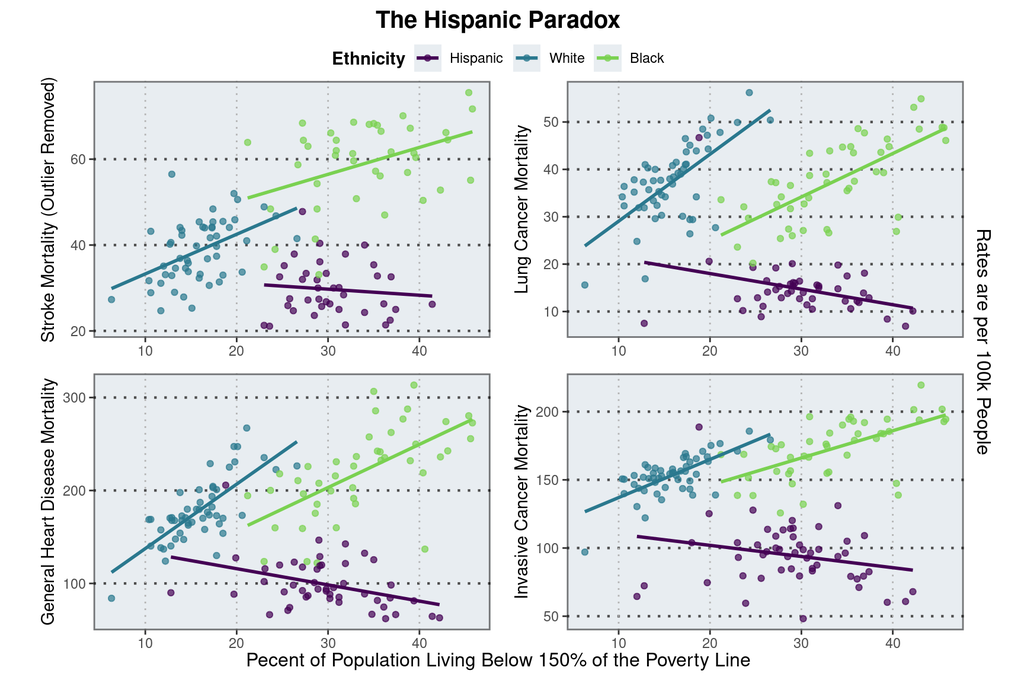

Figure 2. Poverty is positively associated with mortality rates for strokes, lung cancer, heart disease, and invasive cancer for White and Black populations whilst it shows negative/ weaker relationships for Hispanic populations. Data are from the CDC Chronic Disease Indicators dataset (from 2015 to 2022) and represents age-adjusted mortality rates per 100k people across the states in the U.S. Each faceted panel displays a relationship between the percentage of the population that is living below 150% of the poverty line and a mortality outcome (strokes, lung cancer, heart disease, and invasive cancer). Linear regression lines are used to highlight the visible trends among the 3 different ethnicity groups.

```r
StateHealthBWH<-StateHealth|>
    filter(Stratification1 %in% c("Black","White","Hispanic"))



args <- list(
    geom_point(aes(col = Stratification1), alpha = .7,),
    geom_smooth(aes(col = Stratification1), method = "lm", se = F,),
    scale_color_viridis(discrete = TRUE, end = .8,direction = 1),
    labs(x = "", col = "Ethnicity"),
    themeMOH(),
    theme(
        axis.title.x = element_text(size = 0),
        legend.margin = margin(
            t = rel(10),
            b = rel(0.9),
            l = rel(1),
            r = rel(1)
        ),
        plot.margin = margin(
            t = rel(5),
            b = rel(1),
            l = rel(10),
            r = rel(5)
        )),
    xlab("")
)


a <- StateHealthBWH|>
    filter(StrokeMortality <= 100)|>
    ggplot(aes(x = LivingBelow1.5Poverty, y = StrokeMortality)) +args+
    labs(y="Stroke Mortality (Outlier Removed)")

b <- ggplot(StateHealthBWH, aes(x = LivingBelow1.5Poverty, y = LungMortality)) +
    args+
    labs(y="Lung Cancer Mortality")

c <- ggplot(StateHealthBWH, aes(x = LivingBelow1.5Poverty, y = HeartDiseaseMortality)) +
    args+
    labs(y="General Heart Disease Mortality")

d <- ggplot(StateHealthBWH,aes(x = LivingBelow1.5Poverty, y = InvasiveMortality))+
    args+
    labs(y="Invasive Cancer Mortality")




ggarrange(a,b,c,d,
          common.legend = TRUE,
          legend = "top",align = "v"
          )|>
    annotate_figure(
        top = text_grob(
            "The Hispanic Paradox",
            size = rel(15),
            face = "bold",
            vjust = rel(.8)
        ),
        bottom = text_grob(
            "Pecent of Population Living Below 150% of the Poverty Line",
            vjust = rel(-.3)
        ),
        right = "\nRates are per 100k People",
        left = ""
    )
```

**Figure 2 Interpretation:** Higher levels of poverty are associated with increased mortality rates for strokes, lung cancer, heart disease, and invasive cancer under White and Black populations. White and Black populations show positive relationships across all 4 different mortality outcomes which indicates that high levels of poverty and socio-economic status is linked to poorer health and higher mortality rates. For Hispanic populations, the relationship between poverty and mortality rates is weaker and slightly inconsistent. For all 4 different health conditions, there are low mortality rates even at very high levels of poverty. This suggests that other factors beyond just income, such as possible cultural/social influences, play a role in shaping health outcomes for different ethnic groups.[^2] The relationships between poverty and mortality/ health outcomes varies across the different ethnic groups which is important to our research question on how chronic health outcomes in the U.S can vary across different ethnic groups and how much of the outcome can be associated with socioeconomic factors like poverty.[^3]

### Cigarette Smoking and Lung Cancer

**Figure 3:**

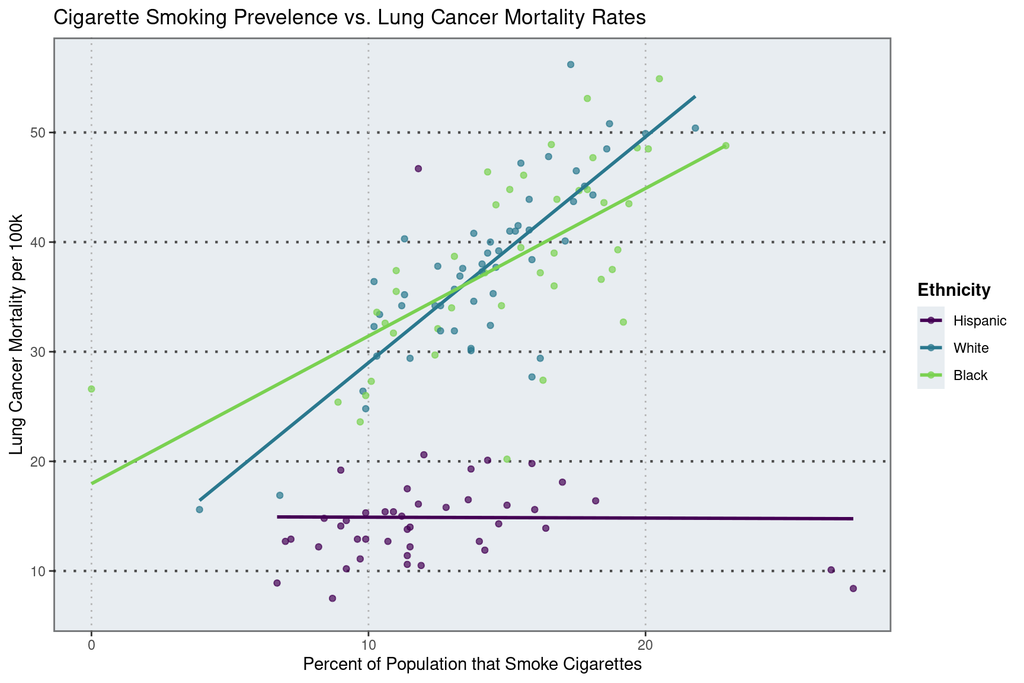

Figure 3. A comparison of cigarette smoking prevalence and lung cancer mortality rates per 100,000 individuals, disaggregated by ethnicity population groups: Hispanic, White, and Black. The scatter plot that includes linear regression lines indicate a strong positive correlation between smoking and mortality for the White and Black populations, with mortality rates rising significantly as smoking prevalence increases. Additionally, the overlapping trends for Black and White populations show that there is not a separate variable or differences in genetics between Black and White populations that causes significantly greater rates of lung cancer for one, beyond the prevalence of cigarette smoking. This shows that, on its own, cigarette smoking is a decent indicator of lung cancer mortality for Black and White populations. However, the Hispanic populations seems to show a ‘flat’ trend line at a lower baseline mortality rate, suggesting that smoking prevalence has a disproportionately lower impact on lung cancer mortality within this group compared to the other

```r
StateHealthBWH|>
    ggplot(aes(x=CigaretteSmoking,y=LungMortality,col=Stratification1))+
    geom_point(alpha=.7)+
    geom_smooth(method = "lm",se=F)+themeMOH()+scale_color_viridis(discrete = TRUE, end = .8,direction = 1)+
    labs(
        title = "Cigarette Smoking Prevelence vs. Lung Cancer Mortality Rates",
        color = "Ethnicity",
        x= "Percent of Population that Smoke Cigarettes",
        y = "Lung Cancer Mortality per 100k"
    )
```

**Figure 3 Interpretation:** The visualization shows a stark difference in how cigarette smoking impacts lung cancer mortality across different ethnic demographics. For the White and Black populations, the data reveals a strong, positive linear correlation , where increases in smoking rates are directly associated with a significant rise in mortality. Conversely, the Hispanic population exhibits what is often referred to in public health as the “Hispanic Paradox.” Despite varying levels of smoking prevalence, the mortality rate for this group remains remarkably stable and significantly lower than the other two groups, as evidenced by the nearly horizontal regression line hovering around 15 deaths per 100,000. This suggests that the relative risk of lung cancer mortality associated with smoking is not uniform across these ethnicities in this specific data set.[^4]

### Physical Health and Cardiovasculur Disease Across Ethnic Groups

**Figure 4:**

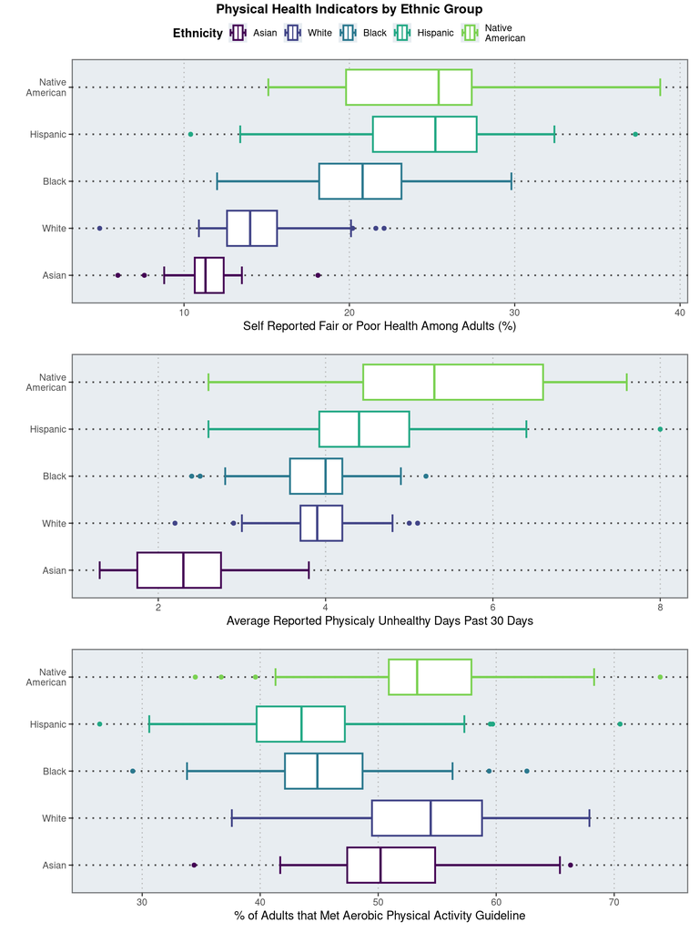

```r
StateHealth.a <- StateHealth |>
    filter(Stratification1 != "Overall")|>
    ungroup() |>
    mutate(
        Stratification1 = fct_reorder(
        Stratification1,FairOrPoorHealth,
        .fun = mean,
        na.rm = T),Stratification1 = fct_recode(
            Stratification1,
            "Native\nAmerican" = "NativeAmerican"),
        )

plotargs <- list(
     geom_boxplot(
        alpha = 1,
        whisker.linewidth = 1,
        staple.linewidth = .8,
        staplewidth = .5,
        box.linewidth = .8
    ),
    themeMOH(),
    scale_color_viridis(discrete = T, end = .8),
    theme(plot.margin = margin_auto(10))
)




a <- StateHealth.a|>
    ggplot(aes(y = Stratification1, x = FairOrPoorHealth, col = Stratification1)) +
    plotargs+
    labs(x="Self Reported Fair or Poor Health Among Adults (%)",y="",col="Ethnicity")


b <- StateHealth.a |>
    ggplot(aes(y = Stratification1, x = AvePhysicalyUnhealthyDays, col = Stratification1)) +
    plotargs+
    labs(x="Average Reported Physicaly Unhealthy Days Past 30 Days",y="",col="Ethnicity")
#uncertain about past 30 days but makes sense for what I could find about the data from https://www.cdc.gov/brfss/annual_data/2024/pdf/2024-calculated-variables-version4-508.pdf



c <- StateHealth.a |>
    ggplot(aes(y = Stratification1, x = MetPhysicalActivityGuideline, col = Stratification1)) +
    plotargs+
    labs(x="% of Adults that Met Aerobic Physical Activity Guideline",y="",col="Ethnicity")



abc <- ggarrange(
    a,
    b,
    c,
    ncol = 1,
    nrow = 3,
    common.legend = T,
    legend = "top"
)|>
    annotate_figure(top  = text_grob("Physical Health Indicators by Ethnic Group",face = "bold"))


abc
```

**Figure 5:**

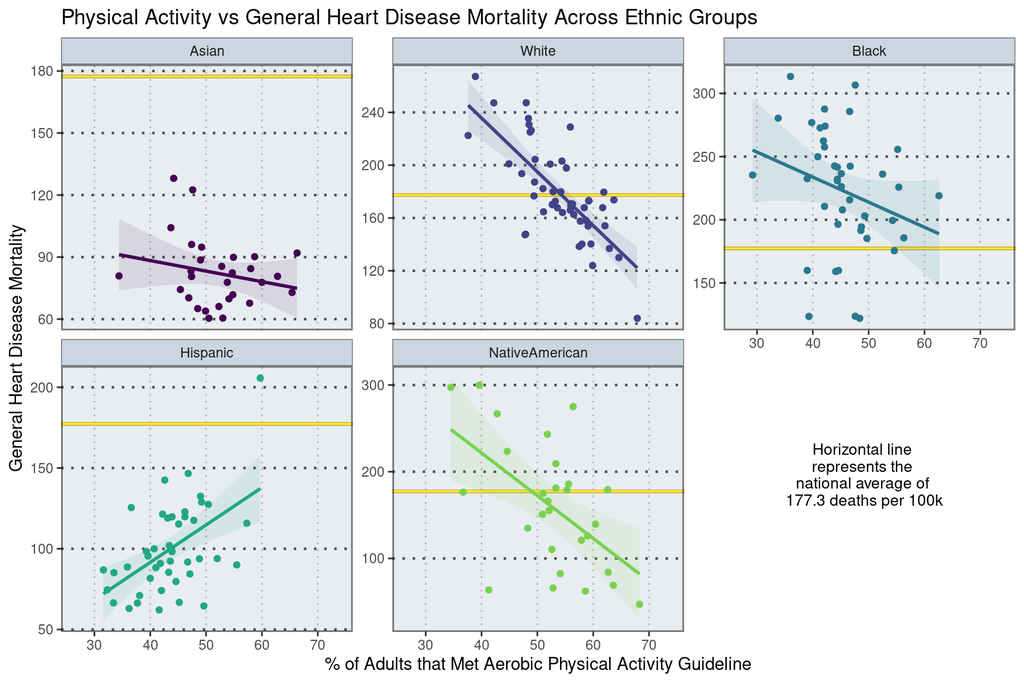

```r
HeartDiseaseNationalAverage <-StateHealth|>
    filter(Stratification1 == "Overall")|>
    group_by(Stratification1)|>
    summarise(nationalAve = mean(HeartDiseaseMortality,na.rm = T))|>
    pull(nationalAve)



StateHealth |>
    filter(StratificationCategory1 != "Overall")|>
    ungroup() |>
    mutate(
        Stratification1 = fct_reorder(
        Stratification1,FairOrPoorHealth,
        .fun = mean,
        na.rm = T)
        ) |>
    ggplot(
        aes(x = MetPhysicalActivityGuideline, y = HeartDiseaseMortality, col = Stratification1)
    ) +
    geom_hline(
        yintercept = HeartDiseaseNationalAverage,
         color = viridis(2, option = "D")[1],
        linewidth = 1
    ) +
    geom_hline(
        yintercept = HeartDiseaseNationalAverage,
         color = viridis(10, option = "D")[10],
        linewidth = .9) +
    geom_point(show.legend = F) +
    geom_smooth(
        aes(fill = Stratification1),
        method = "lm",
        se = T,
        alpha = .1,
        show.legend = F
    ) +


    facet_wrap( ~ Stratification1, scales = "free_y") +
    themeMOH() +
    theme(
        plot.tag.location = "plot",
        plot.tag.position = c(.85, .3),
        plot.tag = element_text(size = rel(.9))
    ) +
    scale_color_viridis(discrete = T, end = .8) +
    scale_fill_viridis(discrete = T, end = .8) +
    labs(x = "% of Adults that Met Aerobic Physical Activity Guideline", #find where guideline is from
         y = "General Heart Disease Mortality",
         tag  = "Horizontal line \nrepresents the \nnational average of \n177.3 deaths per 100k",
         title = "Physical Activity vs General Heart Disease Mortality Across Ethnic Groups")
```

### Health Insurance and Preventative Care in Hispanic Populations

**Figure 6:**

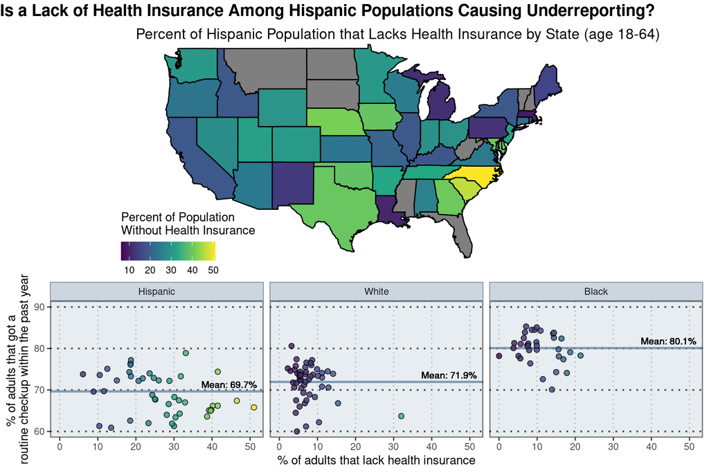

Figure 6. Hispanic populations in the United States tend to have higher percentages of their population who do not have health insurance. However, the lack of health insurance does not seem to impact the percentage of the population that gets routine checkups as both Hispanic and White populations received routine checkups at a similar rate. The average percentage of the population that received a routine checkup in the past year (collected in 2021) was 69.7% for Hispanic populations and 71.9% for White populations. Both of these rates are low compared to the average rate for Black populations which is 80.1%. These findings very tentatively indicate that there is not significant under-reporting of illnesses among Hispanic populations as roughly the same proportion of White and Hispanic populations receive routine checkups. These findings could also be due to many other factors such as lower quality of healthcare received by minority populations leading to under-diagnosis and under-reporting. These findings cannot rule out under-reporting as a potential contributing factor to the Hispanic paradox phenomenon.

```r
county_lines <- map_data("state") |>
    as_tibble()


a <- StateHealth |>
    filter(Stratification1 %in% c("Hispanic")) |>
    mutate(region = tolower(LocationDesc)) |>
    left_join(county_lines, by = "region") |>
    ggplot(aes(long, lat, group = group)) +
    geom_polygon(color = "black", aes(fill = LackOfHealthInsurance)) +
    coord_map() + scale_fill_viridis_c(end = 1 ) +
    labs(title = "Percent of Hispanic Population that Lacks Health Insurance by State (age 18-64)", fill = "Percent of Population \nWithout Health Insurance") +
    theme(
        axis.title.x = element_text(size = 0),
        axis.title.y = element_text(size = 0),
        axis.text.x = element_text(size = 0),
        axis.text.y = element_text(size = 0),
        axis.ticks = element_line(linewidth = 0),
        panel.background = element_rect(fill = fill_alpha(fill = "pink", alpha = 0)),
        legend.background = element_rect(fill = fill_alpha(fill = "pink", alpha = 0)),
        legend.position = "inside",
        legend.position.inside = c(0.1, 0.1),
        legend.direction = "horizontal",
        legend.title.position = "top",
        legend.title = element_text(),
        plot.title.position = "plot",
        plot.title = element_text(margin = margin(b = rel(-10))),
        plot.margin = margin(t=8,l=8 , unit = "pt")
    )

b <- StateHealth |>
    filter(Stratification1 %in% c("Hispanic", "White", "Black")) |>
    group_by(Stratification1) |>
    mutate(meancheckup = mean(RoutineCheckup, na.rm = T)) |>
    ggplot(aes(x = LackOfHealthInsurance, y = RoutineCheckup)) +
    geom_hline(
        aes(yintercept = meancheckup),
        colour = "#6A89A7",
        linewidth = 1,
        alpha = .8,
    ) +
    geom_text(
        aes(x = 44.5,
            y = meancheckup,
            label = paste0("Mean: ",round(meancheckup,1),"%")),
        vjust = -0.5,
        size = 3
    )+
    geom_point(
        aes(fill = LackOfHealthInsurance),
        shape = 21,
        show.legend = F,
        size = 2,
        alpha = .8
    ) +
    facet_wrap( ~ Stratification1) + ylim(60,90)+
    themeMOH() +
    scale_color_viridis(discrete = T, begin =.1) +
    scale_fill_viridis_c() +
    labs(x = "% of adults that lack health insurance",
         y = "% of adults that got a \nroutine checkup within the past year")



ggarrange(
    a,
    b,
    nrow = 2,
    heights = c(1.3, 1),
    common.legend = FALSE
) |>
    annotate_figure(
        top = text_grob(
            "Is a Lack of Health Insurance Among Hispanic Populations Causing Underreporting?",
            size = rel(15),
            x=0,
            face = "bold",
            hjust = rel(0)
        )
    )
```

**Figure 6 Interpretation:** This map visualization show the variation in the percentage of the Hispanic population without health insurance across all U.S states. Most U.S states have a large amount of Hispanic individuals who are uninsured. Although, certain states have much higher rates of uninsured Hispanic individuals which indicates that there is different levels of unequal access to healthcare in different U.S states- whether an Hispanic individual has health insurance or not is dependent on state policies and structures.

However, when we start looking at the relationship between the percentage of adults who have health insurance and the percentage of adults who have gotten a routine checkup over the past year it gets more complicated. This is illustrated by the faceted scatterplots. Despite the fact that Hispanic populations have higher rates of not having health insurance than the White population, the percentage of individuals that have routine checkups over the past year for the two ethnic groups are very similar- the Hispanic group has a mean of 69.7% and the White group has a mean of 71.9%. This suggests that a lack of health insurance doesn’t necessarily prevent Hispanic individuals from using preventative healthcare measures. This could be due to the fact that they had access to lower-cost community healthcare centers.

An important thing to note, is that this goes further than whether an adult has had a routine checkup over the past year or not. Higher levels of individuals that don’t have health insurance can contribute to delayed diagnoses of chronic conditions. Thus, differences in healthcare outcomes for different ethnic groups might be more affected by access to preventative healthcare. So, even whilst utilization of preventative services such as checkups do happen, lack of health insurance can be associated with having delayed diagnoses and worse health outcomes.[^6]

## **Conclusion**

The data analysis done in this project illustrates that chronic health outcomes in the United States are complex and that they are shaped by various factors such as socioeconomic conditions and ethnicity. While the initial analysis confirms a predictable positive correlation between cigarette smoking and lung cancer mortality for White and Black populations, the introduction of poverty as a variable reveals a deeper structural layer to these health disparities. Across multiple conditions like heart disease, stroke, and invasive cancer, higher concentrations of poverty consistently correlate with increased mortality rates for White and Black communities. This suggests that for these groups, economic hardship compounds the biological risks of smoking, likely due to reduced access to preventative care and environmental stressors.

Conversely, the “Hispanic Paradox” persists as a defining outlier throughout this study. The data shows that the Hispanic population consistently maintains lower mortality rates across nearly all studied conditions, displaying a unique resilience to both smoking prevalence and high poverty levels that typically drive mortality in other groups. The relationship between healthcare outcomes and socioeconomic status is not constant across all the different ethnic groups and is affect by other factors.

Ultimately, this project illustrates that public health outcomes are not determined just from one factor but can rather emerge due to many complex influences. Effective health policy must move beyond general anti smoking campaigns to address the specific socioeconomic vulnerabilities of the Black and White populations, while further investigating the protective cultural or systemic factors that contribute to the comparative longevity of the Hispanic demographic.

## **Citations**

[Hispanic Paradox](https://%20/articles/PMC3673509/)

[Cancer Disparities in Different Ethnic Groups](https://www.cancer.gov/about-cancer/understanding/disparities)

[Racial/Ethnic Differences in Cardiovascular Disease Mortality](https://pmc.ncbi.nlm.nih.gov/articles/PMC9937428/)

[Key Facts about the Uninsured Population](https://www.kff.org/uninsured/key-facts-about-the-uninsured-population/?utm_source=chatgpt.com&entry=executive-summary-introduction)

[^1]: “Cancer Disparities,” https://www.cancer.gov/about-cancer/understanding/disparities
[^2]: “Hispanic Mortality Paradox: A Systematic Review and Meta-Analysis,” https://pmc.ncbi.nlm.nih.gov/articles/PMC3673509/
[^3]: “Cancer Disparities,” https://www.cancer.gov/about-cancer/understanding/disparities
[^4]: “Hispanic Mortality Paradox: A Systematic Review and Meta-Analysis,” https://pmc.ncbi.nlm.nih.gov/articles/PMC3673509/
[^5]: “Racial/Ethnic Differences in All-Cause and Cardiovascular Disease Mortality,”https://pmc.ncbi.nlm.nih.gov/articles/PMC9937428/
[^6]: “Key Facts about the Uninsured Population,”https://www.kff.org/uninsured/key-facts-about-the-uninsured-population/?utm_source=chatgpt.com&entry=executive-summary-introduction